# 04 - Reference-based cell-type annotation

Cell types are assigned per cell with SingleR (Aran et al. 2019), using the Dahlin et al. 2018 mouse bone-marrow HSPC atlas as the reference (about 44k LK/LSK cells; the `dataset` field of the object identifies it as Dahlin, and it is the reference used by the source paper).

SingleR scores each cell by Spearman correlation with each reference label on label-specific marker genes and refines the top candidates iteratively. It works on the normalized expression directly, so the annotation does not depend on the Harmony integration. It also returns a confidence score per cell and prunes low-confidence assignments instead of forcing every cell into a label, which the original label transfer did.

The reference’s own `Unassigned` cells are dropped because that label carries no meaning to transfer, and the reference is aggregated into per-label pseudo-cells (`aggr.ref = TRUE`) to keep annotation of 230k cells fast.

The labels are checked two ways below: agreement with the unsupervised clusters from stage 03, and expression of canonical marker genes that do not come from the reference.

```r
library(here)
library(tidyverse)
library(Seurat)
library(SingleR)
library(BiocParallel)

int_dir <- here("data", "processed", "03_integration")
ann_dir <- here("data", "processed", "04_annotation")
dir.create(ann_dir, recursive = TRUE, showWarnings = FALSE)

seu <- readRDS(file.path(int_dir, "seurat_integrated.rds"))
ref <- readRDS(here("data", "reference", "reference_atlas.rds"))
```

## Run SingleR

```r
ref <- subset(ref, subset = celltype != "Unassigned")
ref <- NormalizeData(ref, verbose = FALSE)

set.seed(42)
pred <- SingleR(
  test    = GetAssayData(seu, assay = "RNA", layer = "data"),
  ref     = GetAssayData(ref, assay = "RNA", layer = "data"),
  labels  = ref$celltype,
  aggr.ref = TRUE,
  BPPARAM = MulticoreParam(8)
)

seu$celltype        <- pred$labels
seu$celltype_pruned <- pred$pruned.labels   # NA = low-confidence assignment
seu$singler_delta   <- pred$delta.next

cat(sprintf("Low-confidence (pruned) assignments: %d of %d cells (%.2f%%)\n",
            sum(is.na(pred$pruned.labels)), ncol(seu),
            100 * mean(is.na(pred$pruned.labels))))
```

```
Low-confidence (pruned) assignments: 543 of 230684 cells (0.24%)
```

```r
sort(table(seu$celltype), decreasing = TRUE)
```

```
 Immature       Neu  Late_Ery     Mo_DC   Middle        MEP Early_Ery   Megakry
    36406     33036     32422     27707     24275     17915     17217     14192
     HSCs      Baso       Lym      Mast
    10687      9906      4896      2025
```

## Verification 1 - concordance with unsupervised clusters

Rows are clusters from stage 03, columns are SingleR labels, and values are row proportions. Good annotation shows each cluster dominated by one label or by adjacent developmental stages.

```r
conc <- table(cluster = seu$seurat_clusters, label = seu$celltype)
knitr::kable(round(prop.table(conc, margin = 1), 2))
```

|  | Baso | Early_Ery | HSCs | Immature | Late_Ery | Lym | Mast | Megakry | MEP | Middle | Mo_DC | Neu |
| --- | --- | --- | --- | --- | --- | --- | --- | --- | --- | --- | --- | --- |
| 0 | 0.00 | 0.00 | 0.26 | 0.56 | 0.00 | 0.10 | 0.00 | 0.00 | 0.02 | 0.00 | 0.04 | 0.02 |
| 1 | 0.00 | 0.00 | 0.00 | 0.00 | 0.98 | 0.00 | 0.00 | 0.00 | 0.00 | 0.02 | 0.00 | 0.00 |
| 2 | 0.01 | 0.00 | 0.00 | 0.00 | 0.00 | 0.00 | 0.00 | 0.00 | 0.00 | 0.00 | 0.02 | 0.97 |
| 3 | 0.06 | 0.00 | 0.00 | 0.26 | 0.00 | 0.02 | 0.00 | 0.00 | 0.12 | 0.00 | 0.45 | 0.09 |
| 4 | 0.01 | 0.00 | 0.00 | 0.00 | 0.39 | 0.00 | 0.00 | 0.00 | 0.01 | 0.59 | 0.00 | 0.00 |
| 5 | 0.01 | 0.83 | 0.00 | 0.00 | 0.00 | 0.00 | 0.01 | 0.00 | 0.02 | 0.12 | 0.00 | 0.00 |
| 6 | 0.01 | 0.05 | 0.01 | 0.01 | 0.00 | 0.00 | 0.00 | 0.53 | 0.37 | 0.03 | 0.00 | 0.00 |
| 7 | 0.00 | 0.00 | 0.00 | 0.00 | 0.00 | 0.00 | 0.00 | 0.00 | 0.00 | 0.00 | 0.80 | 0.19 |
| 8 | 0.02 | 0.00 | 0.00 | 0.36 | 0.00 | 0.00 | 0.00 | 0.00 | 0.07 | 0.00 | 0.13 | 0.41 |
| 9 | 0.00 | 0.07 | 0.00 | 0.00 | 0.04 | 0.00 | 0.00 | 0.00 | 0.00 | 0.88 | 0.00 | 0.00 |
| 10 | 0.09 | 0.01 | 0.00 | 0.00 | 0.00 | 0.00 | 0.00 | 0.41 | 0.46 | 0.03 | 0.00 | 0.00 |
| 11 | 0.04 | 0.04 | 0.05 | 0.38 | 0.00 | 0.03 | 0.00 | 0.07 | 0.19 | 0.01 | 0.11 | 0.09 |
| 12 | 0.74 | 0.02 | 0.00 | 0.02 | 0.00 | 0.00 | 0.02 | 0.00 | 0.03 | 0.00 | 0.00 | 0.17 |
| 13 | 0.16 | 0.17 | 0.00 | 0.03 | 0.00 | 0.00 | 0.64 | 0.00 | 0.00 | 0.00 | 0.00 | 0.00 |
| 14 | 0.02 | 0.02 | 0.02 | 0.56 | 0.00 | 0.19 | 0.04 | 0.00 | 0.04 | 0.00 | 0.08 | 0.02 |
| 15 | 0.01 | 0.01 | 0.22 | 0.27 | 0.00 | 0.06 | 0.00 | 0.01 | 0.06 | 0.01 | 0.11 | 0.26 |
| 16 | 0.01 | 0.00 | 0.00 | 0.03 | 0.00 | 0.15 | 0.00 | 0.00 | 0.02 | 0.00 | 0.68 | 0.09 |
| 17 | 0.00 | 0.00 | 0.00 | 0.00 | 0.82 | 0.00 | 0.00 | 0.00 | 0.00 | 0.15 | 0.01 | 0.02 |
| 18 | 0.01 | 0.00 | 0.00 | 0.00 | 0.99 | 0.00 | 0.00 | 0.00 | 0.00 | 0.00 | 0.00 | 0.00 |
| 19 | 0.11 | 0.02 | 0.00 | 0.12 | 0.03 | 0.00 | 0.00 | 0.02 | 0.14 | 0.15 | 0.17 | 0.25 |

## Verification 2 - canonical markers

Marker genes are taken from the hematopoiesis literature, independent of the Dahlin reference. Each label should express its defining genes.

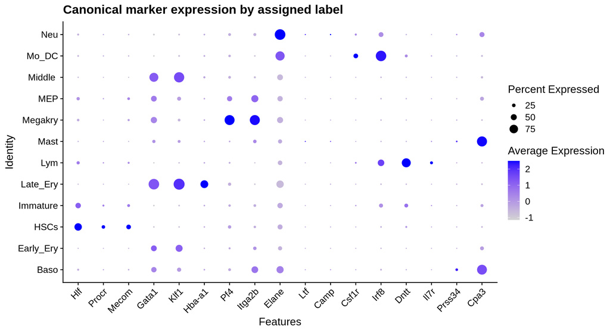

```r
markers <- c(
  Hlf = "HSC", Procr = "HSC", Mecom = "HSC",
  Gata1 = "Ery", Klf1 = "Ery", `Hba-a1` = "Ery",
  Pf4 = "Mk", Itga2b = "Mk",
  Elane = "Neu", Ltf = "Neu", Camp = "Neu",
  Csf1r = "Mono/DC", Irf8 = "Mono/DC",
  Dntt = "Lym", Il7r = "Lym",
  Prss34 = "Baso", Cpa3 = "Mast/Baso"
)
DotPlot(seu, features = names(markers), group.by = "celltype") +
  theme(axis.text.x = element_text(angle = 45, hjust = 1)) +
  labs(title = "Canonical marker expression by assigned label")
```

## Annotated UMAP

```
Rasterizing points since number of points exceeds 100,000.
To disable this behavior set `raster=FALSE`
Rasterizing points since number of points exceeds 100,000.
To disable this behavior set `raster=FALSE`
```

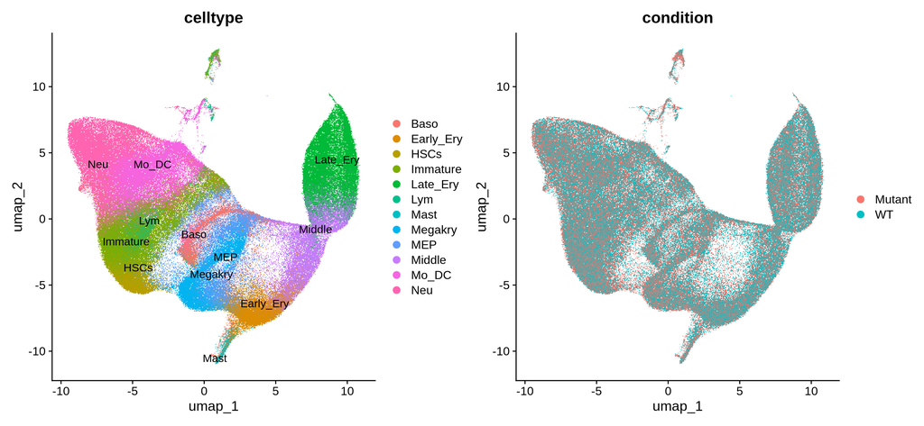

```r
DimPlot(seu, reduction = "umap", group.by = "celltype", label = TRUE, repel = TRUE) +
  DimPlot(seu, reduction = "umap", group.by = "condition")
```

## Save and export for Python stages

The annotated object is saved, and counts, metadata, and embeddings are exported as MatrixMarket and csv files for the Python trajectory stage. Plain formats are used because rds-to-h5ad converters are fragile.

```r
seu[["RNA"]]$scale.data <- NULL            # scaled data is not needed again; saves 3.7 GB
saveRDS(seu, file.path(ann_dir, "seurat_annotated.rds"))
seu[["RNA"]]$data <- NULL                  # normalized layer is not needed for the export below; frees ~8 GB
invisible(gc())

# per-sample cell-type counts for stage 05; dplyr::count spelled out because
# matrixStats (loaded by SingleR) masks count()
celltype_counts <- seu@meta.data %>%
  dplyr::count(gsm, title, model, condition, sex, age, treatment, platform, celltype)
write_csv(celltype_counts, file.path(ann_dir, "celltype_counts.csv"))

export_dir <- file.path(ann_dir, "py_export")
dir.create(export_dir, showWarnings = FALSE)

# stratified subsample for the trajectory stage (up to 2,500 cells per sample, ~90k cells);
# stage 05 uses the full object
set.seed(42)
sub_cells <- seu@meta.data %>% as_tibble(rownames = "cell") %>%
  group_by(gsm) %>% slice_sample(n = 2500) %>% pull(cell)
cat("Export subsample:", length(sub_cells), "cells\n")
```

```
Export subsample: 93364 cells
```

```r
# subset the sparse matrix directly; subsetting the Seurat object would copy every layer
Matrix::writeMM(GetAssayData(seu, layer = "counts")[, sub_cells], file.path(export_dir, "counts.mtx"))
```

```r
write_lines(rownames(seu), file.path(export_dir, "genes.txt"))
write_csv(seu@meta.data[sub_cells, ] %>% as_tibble(rownames = "cell"), file.path(export_dir, "obs.csv"))
write_csv(as_tibble(Embeddings(seu, "harmony")[sub_cells, 1:30], rownames = "cell"),
          file.path(export_dir, "harmony.csv"))
write_csv(as_tibble(Embeddings(seu, "umap")[sub_cells, ], rownames = "cell"),
          file.path(export_dir, "umap.csv"))
cat("Export complete:", length(list.files(export_dir)), "files\n")
```

```
Export complete: 5 files
```